# What Drives Economic Growth in Sub-Saharan Africa?

A panel study of GDP per capita growth, 2000-2023

Author

Philip

Published

October 29, 2026

## Summary

Across 42 Sub-Saharan African economies from 2000 to 2023, per-capita growth picks up after periods of greater trade openness and slows after high inflation and heavy government consumption. In the preferred fixed-effects model, a 10-point rise in trade/GDP is associated with about 0.5 percentage points faster growth the following year, inflation rising from 5% to 25% with about 0.6 points slower growth, and a 5-point rise in government consumption/GDP with about 0.7 points slower growth. Investment, FDI, natural resource rents and population growth show no reliable effect once stable country differences and region-wide shocks are controlled for.

## Question and data

**Question:** Which economic conditions are associated with faster growth in GDP per capita across Sub-Saharan Africa?

| Variable | WDI code | Expected effect |
| --- | --- | --- |
| GDP per capita growth (outcome) | NY.GDP.PCAP.KD.ZG |  |
| Log GDP per capita | NY.GDP.PCAP.KD | Negative (convergence) |
| Investment, % GDP | NE.GDI.TOTL.ZS | Positive |
| Trade, % GDP | NE.TRD.GNFS.ZS | Positive |
| Inflation (log 1 + rate) | FP.CPI.TOTL.ZG | Negative |
| Population growth | SP.POP.GROW | Negative |
| Government consumption, % GDP | NE.CON.GOVT.ZS | Ambiguous |
| FDI inflows, % GDP | BX.KLT.DINV.WD.GD.ZS | Positive |
| Natural resource rents, % GDP | NY.GDP.TOTL.RT.ZS | Ambiguous (“resource curse”) |

Share of country-years missing before cleaning

| Variable | % missing |
| --- | --- |
| gov_cons | 16.6 |
| investment | 15.7 |
| trade | 15.2 |
| resources | 12.0 |
| inflation | 8.9 |
| fdi | 3.0 |
| growth | 2.5 |
| gdppc | 2.4 |
| pop_growth | 0.1 |

## Descriptive picture

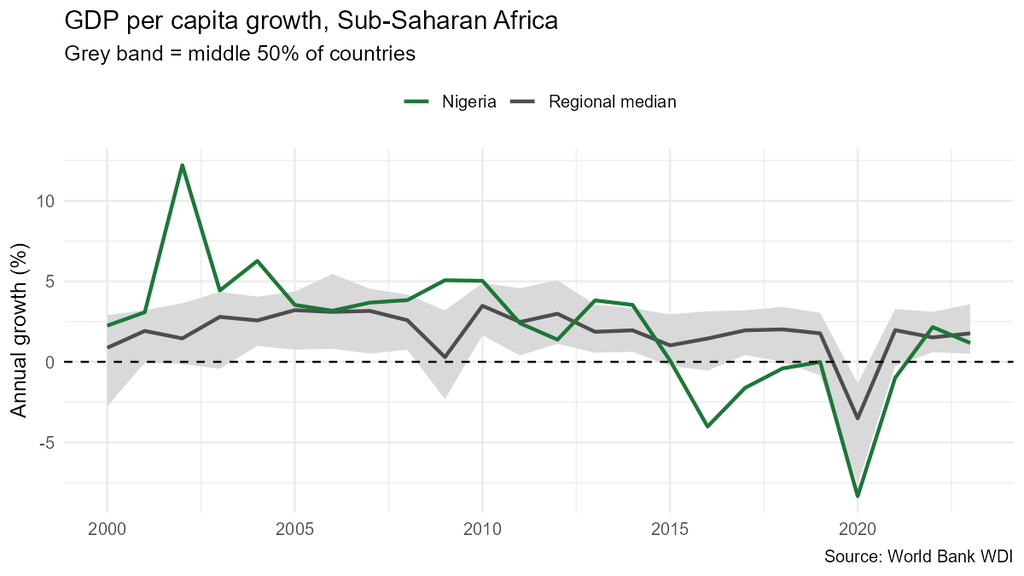

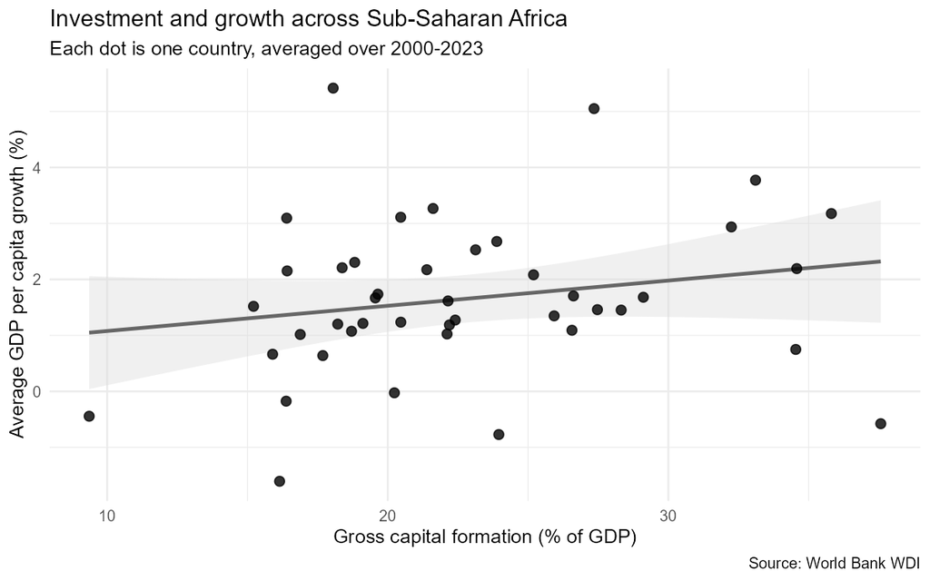

Summary statistics

| variable | n | mean | sd | median | min | max |
| --- | --- | --- | --- | --- | --- | --- |
| fdi | 1101 | 4.12 | 7.78 | 2.42 | -29.94 | 103.34 |
| gov_cons | 949 | 15.09 | 6.77 | 14.09 | 2.05 | 46.26 |
| growth | 1104 | 1.61 | 4.98 | 1.92 | -36.82 | 53.24 |
| inflation | 1034 | 10.19 | 32.91 | 5.37 | -16.86 | 557.20 |
| investment | 951 | 22.81 | 9.59 | 21.68 | 0.00 | 76.78 |
| pop_growth | 1103 | 2.45 | 1.00 | 2.60 | -2.63 | 6.41 |
| resources | 994 | 11.33 | 10.82 | 7.87 | 0.00 | 88.59 |
| trade | 957 | 68.32 | 34.08 | 58.66 | 2.47 | 222.18 |

## Method

Three panel models are estimated: pooled OLS, fixed effects with country and year effects, and random effects. Standard errors are clustered by country. A Hausman test compares fixed and random effects.

Hausman test

| statistic | df | p_value | preferred |
| --- | --- | --- | --- |
| 101.56 | 8 | 0 | Fixed effects |

## Results

Coefficients (clustered standard errors in brackets). * p<0.1, ** p<0.05, *** p<0.01

| term | Pooled OLS | Fixed effects (country + year) | Random effects |
| --- | --- | --- | --- |
| log_gdppc_l1 | -0.890*** (0.302) | -8.430*** (1.710) | -1.150*** (0.329) |
| investment_l1 | 0.049 (0.036) | 0.037 (0.031) | 0.036 (0.034) |
| trade_l1 | 0.012 (0.009) | 0.050*** (0.016) | 0.018 (0.011) |
| infl_log_l1 | -1.660 (1.060) | -3.440*** (1.160) | -2.120** (0.939) |
| pop_growth_l1 | -0.540 (0.353) | -0.173 (0.480) | -0.572 (0.367) |
| gov_cons_l1 | -0.073* (0.042) | -0.148** (0.071) | -0.079* (0.046) |
| fdi_l1 | 0.043 (0.045) | 0.055 (0.046) | 0.054 (0.048) |
| resources_l1 | -0.018 (0.023) | 0.073 (0.054) | 0.002 (0.026) |

Model fit

| model | n_obs | n_countries | r2_within_or_overall |
| --- | --- | --- | --- |
| Pooled OLS | 790 | 42 | 0.055 |
| Fixed effects (country + year) | 790 | 42 | 0.104 |
| Random effects | 790 | 42 | 0.052 |

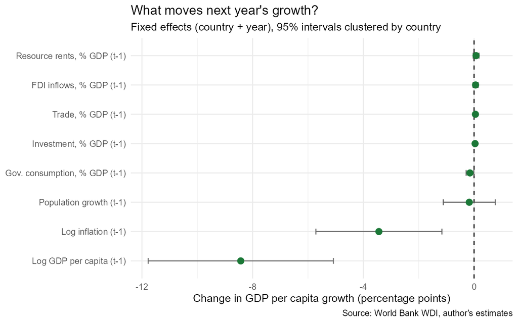

**How to read the fixed-effects results** (the Hausman test rejects random effects, p < 0.001, so fixed effects are preferred):

- **Trade openness (+0.050***):** each extra percentage point of trade/GDP is associated with 0.05 points higher growth the next year, so +10 points of trade means about +0.5 points of growth.
- **Inflation (-3.44***, on log(1 + rate)):** moving from 5% to 25% inflation raises log(1 + rate) by about 0.17, which is associated with about 0.6 points lower growth.
- **Government consumption (-0.148**):** +5 points of GDP is associated with about 0.7 points lower growth.
- **Initial income (-8.43***):** countries grow more slowly after years when they are richer than their own average, a within-country catch-up pattern. Its size should be read with caution (see Limitations).
- **Investment, FDI, resource rents, population growth:** positive or negative signs but not statistically significant. The investment result differs from the simple scatter plot, which mixes differences *between* countries with changes *within* them.

## Robustness

Fixed-effects results with Driscoll-Kraay standard errors, which also allow for shocks common to all countries (such as commodity price swings):

| term | estimate | std_error | p_value |
| --- | --- | --- | --- |
| log_gdppc_l1 | -8.4300 | 1.9000 | 1.08e-05 |
| investment_l1 | 0.0372 | 0.0366 | 3.09e-01 |
| trade_l1 | 0.0498 | 0.0113 | 1.10e-05 |
| infl_log_l1 | -3.4400 | 1.2200 | 4.87e-03 |
| pop_growth_l1 | -0.1730 | 0.4290 | 6.86e-01 |
| gov_cons_l1 | -0.1480 | 0.0839 | 7.82e-02 |
| fdi_l1 | 0.0551 | 0.0477 | 2.48e-01 |
| resources_l1 | 0.0730 | 0.0463 | 1.15e-01 |

The same models are replicated in Stata (`code/stata/models.do`).

## Limitations

- Associations, not proof of cause: lagging the variables reduces but does not remove reverse causality.
- Missing data are not random; smaller and conflict-affected economies report less.
- Country averages hide differences within countries.
- With country fixed effects, the lagged income term is biased downward in short panels (Nickell bias), so its size is overstated; the other coefficients are less affected. A GMM estimator (e.g. `plm::pgmm`) is a natural next step.

## What this means

- **Keep inflation low and stable.** It is the clearest drag on growth in this sample.
- **Open up to trade.** Economies that trade more, relative to their size, grow faster the following year.
- **Watch the size of government consumption.** Rising public consumption is associated with slower growth; spending that raises productivity matters more than spending more.